# IE360_HW2_2019402045

## IE360 HOMEWORK 2

#### Saime Nur Benliler

**Table of Contents**

1. Introduction
2. Data Upload
3. Data Preparation for Linear Regression
4. Linear Regression Model
5. Hybrid Model (Linear Regression and ARIMA model on Residuals)
6. Hourly ARIMA Model
7. Seasonal ARIMA Model
8. Model Comparisons

*Detailed summary of the models and comparison analysis is given in the end under Model Comparisons section*

**1. Introduction**

This report outlines the methods and results of forecasting electricity production using various time series regression and ARIMA models. The goal is to build and compare hybrid methods using ARIMA model, as well as evaluate baseline models. The forecast period for evaluation spans from February 1st to May 15th, 2024. The models considered include:

- Linear Regression Model
- Hybrid Model (Linear Regression + ARIMA on Residuals)
- Hourly ARIMA Model
- SARIMA Model

```python
import pandas as pd
import numpy as np
from datetime import datetime
import statsmodels.api as sm
from statsmodels.tsa.arima.model import ARIMA
from pmdarima import auto_arima

import pandas as pd
import numpy as np
import matplotlib.pyplot as plt
from sklearn.linear_model import LinearRegression
from sklearn.model_selection import train_test_split
from sklearn.metrics import mean_squared_error, r2_score
import statsmodels.api as sm
from sklearn.decomposition import PCA
from sklearn.preprocessing import StandardScaler
import seaborn as sns
from datetime import datetime, timedelta
from prettytable import PrettyTable
```

**2. Data Upload**

While the weather information collected across various grid points provides a comprehensive dataset, its individual analysis might not be the most practical approach. The expansive areas encompassed by each grid point, relative to the specific location of the solar power plant, can limit the actionable insights from this data. Additionally, variables like cloud cover, temperature, and downward shortwave radiation flux (DSWR) tend to exhibit high levels of correlation at this scale. To address these limitations and explore potentially more meaningful relationships, the decision was made to **calculate average values** for each weather variable across all grid points. This approach not only mitigates the issue of multicollinearity observed in the visualizations of the coordinate-based data but also simplifies the analysis by focusing on central tendencies within the surrounding area.

```python
weather_info_path = './weather_info.csv'
weather_info_df = pd.read_csv(weather_info_path)

# Combining 'date' and 'hour' into a single datetime column at the start
weather_info_df['datetime'] = pd.to_datetime(weather_info_df['date'] +
                                             ' ' + weather_info_df['hour'].astype(str) + ':00')

# Moving 'datetime' to the first column
column_order = ['datetime'] + [col for col in weather_info_df.columns if col != 'datetime']
weather_info_df = weather_info_df[column_order]

weather_info_df.drop(['date', 'hour'], axis=1, inplace=True)

column_names_list = weather_info_df.columns.tolist()

weather_info_df = weather_info_df.groupby('datetime')[column_names_list[3:]].mean().reset_index()

# Display the updated DataFrame
weather_info_df.head(24)
```

|  | datetime | DSWRF_surface | TCDC_low.cloud.layer | TCDC_middle.cloud.layer | TCDC_high.cloud.layer | TCDC_entire.atmosphere | USWRF_top_of_atmosphere | CSNOW_surface | DLWRF_surface | USWRF_surface | TMP_surface |
| --- | --- | --- | --- | --- | --- | --- | --- | --- | --- | --- | --- |
| 0 | 2022-01-01 04:00:00 | 0.0000 | 2.384 | 5.944 | 4.604 | 14.296 | 0.00000 | 0.00 | 227.999 | 0.00000 | 269.220 |
| 1 | 2022-01-01 05:00:00 | 0.0000 | 2.784 | 4.324 | 10.636 | 19.272 | 0.00000 | 0.00 | 227.774 | 0.00000 | 269.104 |
| 2 | 2022-01-01 06:00:00 | 0.0000 | 2.964 | 5.372 | 11.688 | 21.772 | 0.00000 | 0.00 | 227.764 | 0.00000 | 269.035 |
| 3 | 2022-01-01 07:00:00 | 0.0000 | 3.284 | 9.212 | 20.736 | 31.992 | 0.00000 | 0.00 | 228.196 | 0.00000 | 269.001 |
| 4 | 2022-01-01 08:00:00 | 0.0000 | 3.672 | 11.252 | 26.432 | 38.376 | 0.00000 | 0.00 | 228.657 | 0.00000 | 269.002 |
| 5 | 2022-01-01 09:00:00 | 7.3688 | 4.120 | 10.880 | 35.088 | 45.856 | 8.96704 | 0.00 | 229.416 | 2.41280 | 271.634 |
| 6 | 2022-01-01 10:00:00 | 180.1384 | 4.180 | 13.748 | 80.764 | 85.364 | 135.20448 | 0.00 | 237.291 | 59.18848 | 275.786 |
| 7 | 2022-01-01 11:00:00 | 254.7928 | 3.972 | 16.520 | 69.392 | 75.468 | 152.98944 | 0.00 | 237.387 | 82.53120 | 278.553 |
| 8 | 2022-01-01 12:00:00 | 312.5520 | 4.408 | 23.468 | 60.516 | 70.368 | 167.55392 | 0.00 | 238.387 | 99.73056 | 280.215 |
| 9 | 2022-01-01 13:00:00 | 347.4144 | 5.348 | 32.996 | 54.852 | 70.452 | 180.69312 | 0.00 | 240.887 | 109.43168 | 280.609 |
| 10 | 2022-01-01 14:00:00 | 364.6544 | 6.772 | 39.460 | 45.880 | 71.136 | 187.03872 | 0.00 | 243.015 | 113.51040 | 280.277 |
| 11 | 2022-01-01 15:00:00 | 362.2984 | 9.116 | 43.452 | 39.864 | 71.612 | 188.88640 | 0.00 | 245.296 | 112.10304 | 279.165 |
| 12 | 2022-01-01 16:00:00 | 221.4584 | 37.100 | 82.296 | 12.680 | 89.116 | 168.56448 | 0.00 | 260.756 | 66.06976 | 277.059 |
| 13 | 2022-01-01 17:00:00 | 157.6448 | 37.032 | 78.252 | 17.376 | 85.688 | 133.18080 | 0.00 | 258.960 | 47.22432 | 273.467 |
| 14 | 2022-01-01 18:00:00 | 107.3080 | 35.876 | 74.752 | 27.016 | 83.300 | 92.25216 | 0.00 | 257.256 | 32.11968 | 271.659 |
| 15 | 2022-01-01 19:00:00 | 80.4792 | 35.080 | 72.480 | 37.268 | 83.508 | 69.18720 | 0.00 | 256.506 | 24.08960 | 271.537 |
| 16 | 2022-01-01 20:00:00 | 64.3864 | 36.096 | 75.236 | 44.544 | 85.644 | 55.34976 | 0.00 | 257.705 | 19.27104 | 271.715 |
| 17 | 2022-01-01 21:00:00 | 53.6528 | 37.028 | 77.632 | 49.756 | 87.520 | 46.12352 | 0.00 | 259.485 | 16.06016 | 271.855 |
| 18 | 2022-01-01 22:00:00 | 0.0000 | 49.732 | 90.688 | 68.948 | 98.276 | 0.00000 | 0.00 | 272.875 | 0.00000 | 272.029 |
| 19 | 2022-01-01 23:00:00 | 0.0000 | 56.532 | 92.580 | 69.140 | 98.380 | 0.00000 | 0.00 | 274.722 | 0.00000 | 272.231 |
| 20 | 2022-01-02 00:00:00 | 0.0000 | 66.812 | 94.140 | 76.844 | 98.760 | 0.00000 | 0.04 | 280.774 | 0.00000 | 272.513 |
| 21 | 2022-01-02 01:00:00 | 0.0000 | 71.096 | 94.212 | 80.404 | 98.492 | 0.00000 | 0.20 | 283.754 | 0.00000 | 272.616 |
| 22 | 2022-01-02 02:00:00 | 0.0000 | 74.580 | 94.000 | 84.192 | 98.792 | 0.00000 | 0.32 | 287.346 | 0.00000 | 273.024 |
| 23 | 2022-01-02 03:00:00 | 0.0000 | 77.660 | 94.556 | 86.644 | 98.980 | 0.00000 | 0.48 | 291.060 | 0.00000 | 273.426 |

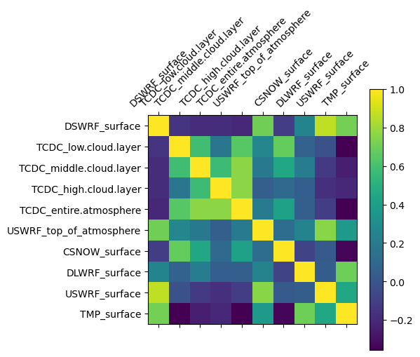

```python
correlation_matrix = weather_info_df.corr()
plt.matshow(correlation_matrix)
plt.xticks(range(len(correlation_matrix.columns)), correlation_matrix.columns, rotation=45)
plt.yticks(range(len(correlation_matrix.columns)), correlation_matrix.columns)
plt.colorbar()
plt.show()
```

```python
production_path = './production.csv'
production_df = pd.read_csv(production_path)

# Combine 'date' and 'hour' into a single datetime column
production_df['datetime'] = pd.to_datetime(production_df['date'] + ' ' + production_df['hour'].astype(str) + ':00')

# Move 'datetime' to the first column
column_order = ['datetime'] + [col for col in production_df.columns if col != 'datetime']
production_df = production_df[column_order]

# Drop the old date and hour columns
production_df.drop(['date', 'hour'], axis=1, inplace=True)

# Display the modified production dataframe
production_df.head(24)
```

|  | datetime | production |
| --- | --- | --- |
| 0 | 2022-01-01 00:00:00 | 0.00 |
| 1 | 2022-01-01 01:00:00 | 0.00 |
| 2 | 2022-01-01 02:00:00 | 0.00 |
| 3 | 2022-01-01 03:00:00 | 0.00 |
| 4 | 2022-01-01 04:00:00 | 0.00 |
| 5 | 2022-01-01 05:00:00 | 0.00 |
| 6 | 2022-01-01 06:00:00 | 0.00 |
| 7 | 2022-01-01 07:00:00 | 0.00 |
| 8 | 2022-01-01 08:00:00 | 3.40 |
| 9 | 2022-01-01 09:00:00 | 6.80 |
| 10 | 2022-01-01 10:00:00 | 9.38 |
| 11 | 2022-01-01 11:00:00 | 7.65 |
| 12 | 2022-01-01 12:00:00 | 6.80 |
| 13 | 2022-01-01 13:00:00 | 5.10 |
| 14 | 2022-01-01 14:00:00 | 5.10 |
| 15 | 2022-01-01 15:00:00 | 1.70 |
| 16 | 2022-01-01 16:00:00 | 0.00 |
| 17 | 2022-01-01 17:00:00 | 0.00 |
| 18 | 2022-01-01 18:00:00 | 0.00 |
| 19 | 2022-01-01 19:00:00 | 0.00 |
| 20 | 2022-01-01 20:00:00 | 0.00 |
| 21 | 2022-01-01 21:00:00 | 0.00 |
| 22 | 2022-01-01 22:00:00 | 0.00 |
| 23 | 2022-01-01 23:00:00 | 0.00 |

```python
production_df = production_df[production_df['datetime'] >= '2022-02-01']
weather_info_df = weather_info_df[weather_info_df['datetime'] >= '2022-02-01']
```

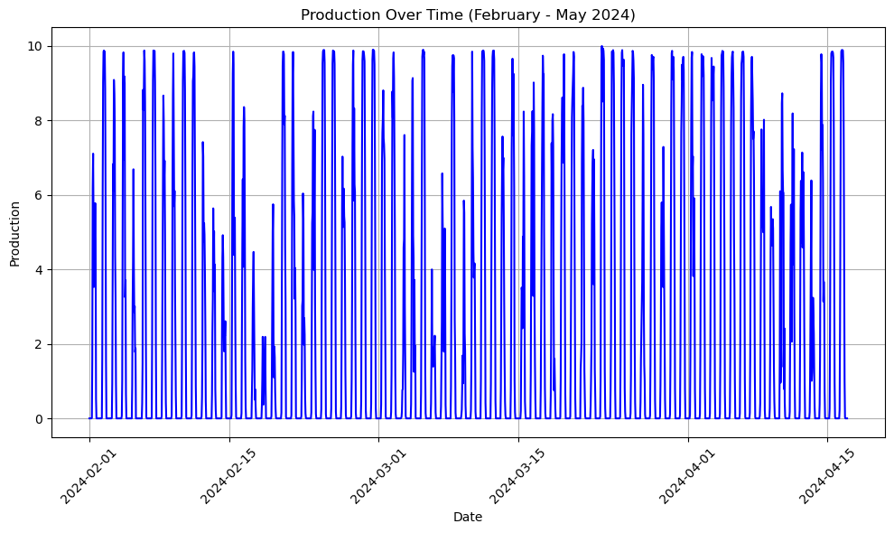

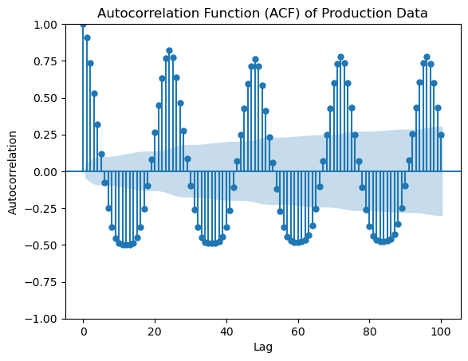

```python
filtered_production_df = production_df[(production_df['datetime'] >= '2024-02-01') & (production_df['datetime'] < '2024-06-01')]

# Plot production over time
plt.figure(figsize=(10, 6))
plt.plot(filtered_production_df['datetime'], filtered_production_df['production'], color='blue')
plt.title('Production Over Time (February - May 2024)')
plt.xlabel('Date')
plt.ylabel('Production')
plt.xticks(rotation=45)
plt.grid(True)
plt.tight_layout()
plt.show()

# ACF Plot
sm.graphics.tsa.plot_acf(filtered_production_df['production'], lags=100)
plt.title('Autocorrelation Function (ACF) of Production Data')
plt.xlabel('Lag')
plt.ylabel('Autocorrelation')
plt.show()
```

Daily seasonality for the production data is easily observed. Production volume at hour h in the last day and production at hour h in the previous days are correlated. Therefore, the effects of each variable might differ considerably for different production hours.

Therefore, one of our approaches will be to divide the production data into 24 hours and make predictions for each hourly data for the next day. Thus, at the end, there will be 24 different models at best, given that there are distinct models for each hour. (Hourly auto.arima model)

```python
merged_df = pd.merge(production_df, weather_info_df, on='datetime', how='inner')
merged_df = merged_df.dropna()
merged_df.head(12)
```

|  | datetime | production | DSWRF_surface | TCDC_low.cloud.layer | TCDC_middle.cloud.layer | TCDC_high.cloud.layer | TCDC_entire.atmosphere | USWRF_top_of_atmosphere | CSNOW_surface | DLWRF_surface | USWRF_surface | TMP_surface |
| --- | --- | --- | --- | --- | --- | --- | --- | --- | --- | --- | --- | --- |
| 0 | 2022-01-01 04:00:00 | 0.00 | 0.0000 | 2.384 | 5.944 | 4.604 | 14.296 | 0.00000 | 0.0 | 227.999 | 0.00000 | 269.220 |
| 1 | 2022-01-01 05:00:00 | 0.00 | 0.0000 | 2.784 | 4.324 | 10.636 | 19.272 | 0.00000 | 0.0 | 227.774 | 0.00000 | 269.104 |
| 2 | 2022-01-01 06:00:00 | 0.00 | 0.0000 | 2.964 | 5.372 | 11.688 | 21.772 | 0.00000 | 0.0 | 227.764 | 0.00000 | 269.035 |
| 3 | 2022-01-01 07:00:00 | 0.00 | 0.0000 | 3.284 | 9.212 | 20.736 | 31.992 | 0.00000 | 0.0 | 228.196 | 0.00000 | 269.001 |
| 4 | 2022-01-01 08:00:00 | 3.40 | 0.0000 | 3.672 | 11.252 | 26.432 | 38.376 | 0.00000 | 0.0 | 228.657 | 0.00000 | 269.002 |
| 5 | 2022-01-01 09:00:00 | 6.80 | 7.3688 | 4.120 | 10.880 | 35.088 | 45.856 | 8.96704 | 0.0 | 229.416 | 2.41280 | 271.634 |
| 6 | 2022-01-01 10:00:00 | 9.38 | 180.1384 | 4.180 | 13.748 | 80.764 | 85.364 | 135.20448 | 0.0 | 237.291 | 59.18848 | 275.786 |
| 7 | 2022-01-01 11:00:00 | 7.65 | 254.7928 | 3.972 | 16.520 | 69.392 | 75.468 | 152.98944 | 0.0 | 237.387 | 82.53120 | 278.553 |
| 8 | 2022-01-01 12:00:00 | 6.80 | 312.5520 | 4.408 | 23.468 | 60.516 | 70.368 | 167.55392 | 0.0 | 238.387 | 99.73056 | 280.215 |
| 9 | 2022-01-01 13:00:00 | 5.10 | 347.4144 | 5.348 | 32.996 | 54.852 | 70.452 | 180.69312 | 0.0 | 240.887 | 109.43168 | 280.609 |
| 10 | 2022-01-01 14:00:00 | 5.10 | 364.6544 | 6.772 | 39.460 | 45.880 | 71.136 | 187.03872 | 0.0 | 243.015 | 113.51040 | 280.277 |
| 11 | 2022-01-01 15:00:00 | 1.70 | 362.2984 | 9.116 | 43.452 | 39.864 | 71.612 | 188.88640 | 0.0 | 245.296 | 112.10304 | 279.165 |

**3. Data Preparation for Linear Regression**

The data preparation is done by fitting linear regression and checking residuals after addition of a new variable like monthly dummy variables, lagged terms, etc.

##### Addition of lagged variable:

Firstly a lag immplementation is done for 72 hours lag in the production data and it is added as predictor to the model. Lag(24) and lag(48) cannot be used since prediction for d+1 is made by the past production data up until the end of day d-2.

##### Hour Filter

By visually inspecting the production data, it can be seen that production outside of hour 6.00 and 19.00 is usually 0. This is because of the sunlight duration in the day. Therefore data is filtered.

##### Lagged Temperature

Surface temperature affects the production with 1 hour lag because of the accumulation of heat in the surface. Therefore, 1 hour shift is added for the TMP_surface variable.

##### Hourly and Monthly dummy Variables

Since the data includes seasonality and there is still trend in the residuals vs fitted plots in previous regressions, seasonal dummy variables are added to the model. Hourly seasonal variable is because of the sunlight effect in different hours of the day. Monthly seasonal variable is because of teh summer and winter effect.

```
                            OLS Regression Results
==============================================================================
Dep. Variable:             production   R-squared:                       0.780
Model:                            OLS   Adj. R-squared:                  0.779
Method:                 Least Squares   F-statistic:                     1103.
Date:                Thu, 06 Jun 2024   Prob (F-statistic):               0.00
Time:                        10:43:42   Log-Likelihood:                -22115.
No. Observations:               10912   AIC:                         4.430e+04
Df Residuals:                   10876   BIC:                         4.457e+04
Df Model:                          35
Covariance Type:            nonrobust
===========================================================================================
                              coef    std err          t      P>|t|      [0.025      0.975]
-------------------------------------------------------------------------------------------
const                     -13.3024      1.879     -7.079      0.000     -16.986      -9.619
DSWRF_surface               0.0023      0.000      6.778      0.000       0.002       0.003
TCDC_low.cloud.layer       -0.0059      0.001     -4.023      0.000      -0.009      -0.003
TCDC_middle.cloud.layer    -0.0009      0.001     -0.943      0.346      -0.003       0.001
TCDC_high.cloud.layer      -0.0011      0.001     -1.006      0.315      -0.003       0.001
TCDC_entire.atmosphere     -0.0069      0.001     -5.166      0.000      -0.010      -0.004
USWRF_top_of_atmosphere     0.0009      0.001      1.722      0.085      -0.000       0.002
CSNOW_surface              -0.8870      0.144     -6.149      0.000      -1.170      -0.604
DLWRF_surface              -0.0143      0.002     -8.707      0.000      -0.018      -0.011
USWRF_surface               0.0017      0.001      2.338      0.019       0.000       0.003
TMP_surface                 0.4672      0.014     33.596      0.000       0.440       0.494
lag_3                       0.1393      0.008     17.390      0.000       0.124       0.155
TMP_1                      -0.3883      0.016    -24.536      0.000      -0.419      -0.357
is_April                   -1.1511      0.176     -6.541      0.000      -1.496      -0.806
is_August                  -1.4381      0.232     -6.199      0.000      -1.893      -0.983
is_December                -1.1752      0.147     -8.011      0.000      -1.463      -0.888
is_February                -0.5772      0.139     -4.144      0.000      -0.850      -0.304
is_January                 -1.3122      0.141     -9.305      0.000      -1.589      -1.036
is_July                    -1.2865      0.212     -6.075      0.000      -1.702      -0.871
is_June                    -1.1668      0.191     -6.098      0.000      -1.542      -0.792
is_March                   -0.6073      0.158     -3.841      0.000      -0.917      -0.297
is_May                     -1.1218      0.186     -6.023      0.000      -1.487      -0.757
is_November                -1.2398      0.158     -7.857      0.000      -1.549      -0.930
is_October                 -1.0558      0.176     -5.987      0.000      -1.402      -0.710
is_September               -1.1706      0.208     -5.616      0.000      -1.579      -0.762
hour_7                     -1.4020      0.163     -8.620      0.000      -1.721      -1.083
```

[output cut: 8 more lines]

```
hour_16                    -2.1249      0.195    -10.908      0.000      -2.507      -1.743
hour_17                    -2.7131      0.181    -14.966      0.000      -3.069      -2.358
hour_18                    -2.8990      0.164    -17.678      0.000      -3.220      -2.578
hour_19                    -2.9237      0.147    -19.948      0.000      -3.211      -2.636
==============================================================================
Omnibus:                      833.218   Durbin-Watson:                   0.793
Prob(Omnibus):                  0.000   Jarque-Bera (JB):             1787.443
Skew:                          -0.501   Prob(JB):                         0.00
Kurtosis:                       4.711   Cond. No.                     2.47e+18
==============================================================================

Notes:
[1] Standard Errors assume that the covariance matrix of the errors is correctly specified.
[2] The smallest eigenvalue is 8.39e-28. This might indicate that there are
strong multicollinearity problems or that the design matrix is singular.
```

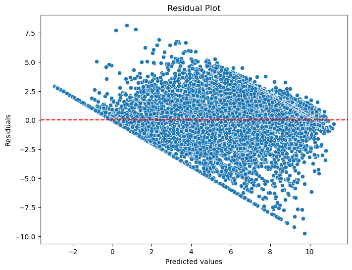

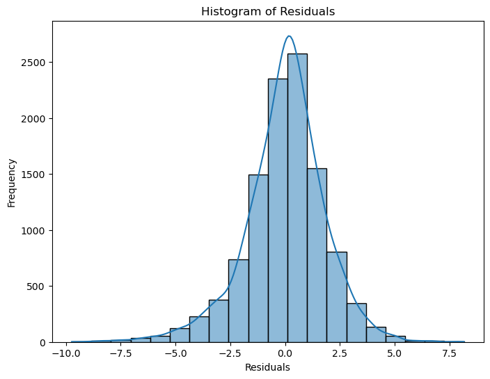

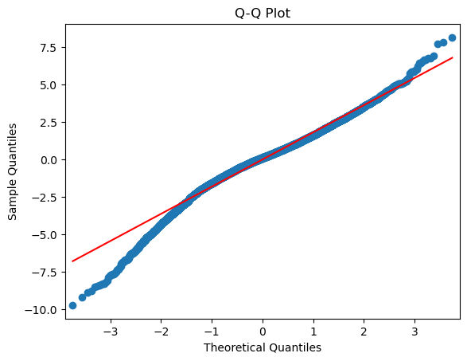

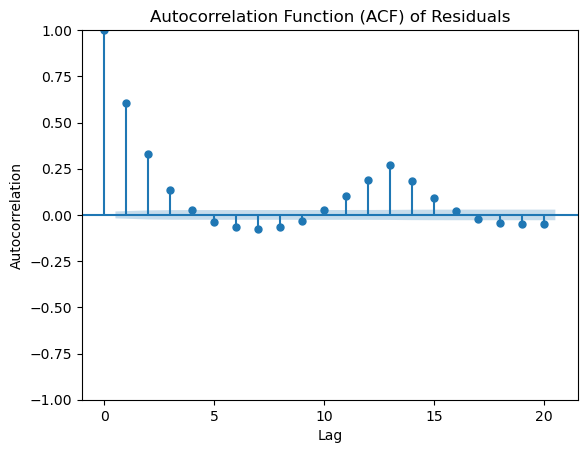

```python
filtered_df7 = pd.merge(production_df, weather_info_df, on='datetime', how='inner')

filtered_df7['lag_3'] = filtered_df7['production'].shift(72)
filtered_df7['TMP_1'] = filtered_df7['TMP_surface'].shift(1)
#filtered_df7['production_diff'] = filtered_df7['production'].diff(24)

filtered_df7['hour'] = filtered_df7['datetime'].dt.hour
filtered_df7['month'] = filtered_df7['datetime'].dt.month

filtered_df7 = filtered_df7[~((filtered_df7['datetime'].dt.hour >= 20) | (filtered_df7['datetime'].dt.hour <= 6))]
filtered_df7['month_name'] = filtered_df7['month'].apply(lambda x: pd.to_datetime('2023-'+str(x)+'-01').strftime('%B'))

month_dummies = pd.get_dummies(filtered_df7['month_name'], prefix='is')


# Join the dummy variables with the original DataFrame
filtered_df7 = pd.concat([filtered_df7, month_dummies], axis=1)

filtered_df7.drop(['month', 'month_name'], axis=1, inplace=True)

hours_to_include = list(range(7, 20))  # This will include 7 to 19

for hour in hours_to_include:
   filtered_df7[f'hour_{hour}'] = (filtered_df7['hour'] == hour).astype(int)

filtered_df7.drop('hour', axis=1, inplace=True)
filtered_df7 = filtered_df7.dropna()

X = filtered_df7.drop(['datetime', 'production'], axis=1)  # Features
y = filtered_df7['production']  # Target variable

X = sm.add_constant(X)
model = sm.OLS(y, X).fit()

print(model.summary())

# Residuals
residuals = model.resid

# Residual Plot
plt.figure(figsize=(8, 6))
sns.scatterplot(model.predict(), residuals)
plt.axhline(y=0, color='r', linestyle='--')
plt.title('Residual Plot')
plt.xlabel('Predicted values')
plt.ylabel('Residuals')
plt.show()

# Histogram of Residuals
plt.figure(figsize=(8, 6))
sns.histplot(residuals, bins=20, edgecolor='k',kde=True)
plt.title('Histogram of Residuals')
plt.xlabel('Residuals')
plt.ylabel('Frequency')
plt.show()

# Q-Q Plot (Quantile-Quantile Plot)
sm.qqplot(residuals, line='r')
plt.title('Q-Q Plot')
plt.show()

# ACF Plot
sm.graphics.tsa.plot_acf(residuals, lags=20)
plt.title('Autocorrelation Function (ACF) of Residuals')
plt.xlabel('Lag')
plt.ylabel('Autocorrelation')
plt.show()
```

The p values of the explanatory variables added by us (lag(3), temperature lag) are very low. So they perform well in terms of explaining the relation.

The effect of dummy variables is not obvious in residual analysis however, by looking at the p values, we can conclude that they explain the variability in the response.

Also, visual inspection strongly encourages us for seasonal dummy variables.

**4. Base Linear regression Model**

Expanding Retraining Window for Time Series Cross-Validation:

A key aspect of the approach is the implementation of an expanding retraining window for time series cross-validation. This strategy addresses the challenge of non-stationary data, which is common in time series forecasting.

Here's how the expanding retraining window works:

The model is initially trained using data up to a specific point in time (e.g., February 1st). Predictions are made for a designated future period (e.g., the next day). After the actual values for the predicted period become available (e.g., after the next day), the model is retrained. The retraining process incorporates the new data, essentially expanding the training window. This helps the model adapt to any evolving trends or patterns in the data. Steps 2-4 are repeated for subsequent prediction periods, with the training window continually expanding to include the latest available data.

This approach offers several advantages:

Improved Accuracy: By incorporating the latest data into the training process, the model can potentially adapt to changing patterns and improve its prediction accuracy over time. Adaptability to Non-Stationarity: The expanding window helps the model handle non-stationarity by continuously updating its understanding of the underlying relationships.

Day-Ahead Prediction with One-Day Lag Training:

```python
def forecast_solar_production(production_df, weather_info_df):
    # Merge production and weather data on datetime
    df = pd.merge(production_df, weather_info_df, on='datetime', how='inner')

    # Initialize the model
    model = LinearRegression()

    df['lag_3'] = df['production'].shift(72)

    df['TMP_1'] = df['TMP_surface'].shift(1)

    df = df[~((df['datetime'].dt.hour >= 20) | (df['datetime'].dt.hour <= 5))]

    df['hour'] = df['datetime'].dt.hour
    df['month'] = df['datetime'].dt.month

    df['month_name'] = df['month'].apply(lambda x: pd.to_datetime(f'2023-{int(x):02d}-01').strftime('%B') if pd.notna(x) else 'Unknown')

    month_dummies = pd.get_dummies(df['month_name'], prefix='is')

    # Join the dummy variables with the original DataFrame
    df = pd.concat([df, month_dummies], axis=1)

    df.drop(['month', 'month_name'], axis=1, inplace=True)

    hours_to_include = list(range(6, 20))  # This will include 6 to 19

    for hour in hours_to_include:
        df[f'hour_{hour}'] = (df['hour'] == hour).astype(int)

    df.drop('hour', axis=1, inplace=True)
    df = df.dropna()

    # Define the start and end dates for prediction
    start_date = pd.to_datetime('2024-02-01')
    end_date = pd.to_datetime('2024-05-15')

    # Create a list to store predictions and WMAPE calculations
    predictions = []
    wmape_values = []

    # Loop through each day in the prediction period
    current_date = start_date
    while current_date <= end_date:
        # Define the training period
        train_end_date = current_date - pd.Timedelta(days=2)

        # Create training data
        train_data = df[df['datetime'] <= train_end_date]

        # Create test data
        test_start_date = current_date
        test_end_date = current_date + pd.Timedelta(hours=23)
        test_data = df[(df['datetime'] >= test_start_date) & (df['datetime'] <= test_end_date)]

        if train_data.empty or test_data.empty:
            current_date += pd.Timedelta(days=1)
            continue

        # Define features and target
        X_train = train_data.drop(columns=['datetime', 'production'])
        y_train = train_data['production']
        X_test = test_data.drop(columns=['datetime', 'production'])
        y_test = test_data['production']

        # Train the model
        model.fit(X_train, y_train)

        # Predict the production for the next 24 hours using linear regression
        y_pred_lr = model.predict(X_test)

        # Calculate residuals
        residuals = y_train - model.predict(X_train)

        # Combine linear regression predictions with ARIMA residual predictions
        y_pred = []
        for date, lr_pred in zip(test_data['datetime'], y_pred_lr):
            if 6 <= date.hour <= 19:
                y_pred.append(lr_pred)
            else:
                y_pred.append(0)

        # Store the predictions with the corresponding datetime
        for date, pred, in zip(test_data['datetime'], y_pred):
            predictions.append({'datetime': date, 'predicted_production': pred})

        # Calculate WMAPE for the current day
        if sum(y_test) != 0:
            wmape = (sum(abs(y_test - y_pred)) / sum(y_test))
        else:
            wmape = float('inf')

        wmape_values.append({'date': current_date, 'WMAPE': wmape})

        # Move to the next day
        current_date += pd.Timedelta(days=1)

    # Convert predictions to DataFrame
    predictions_df = pd.DataFrame(predictions)
    wmape_df = pd.DataFrame(wmape_values)

    # Calculate overall WMAPE for predictions_df
    merged_df = pd.merge(production_df, predictions_df, on='datetime', how='inner')
    total_production = merged_df['production'].sum()
    total_absolute_error = abs(merged_df['production'] - merged_df['predicted_production']).sum()

    if total_production != 0:
        overall_wmape = (total_absolute_error / total_production)
    else:
        overall_wmape = float('inf')

    date_range = pd.date_range(start=merged_df['datetime'].min().normalize(),
                   end=merged_df['datetime'].max().normalize() + pd.Timedelta(days=1) - pd.Timedelta(hours=1),
                   freq='H')

    # Create a new dataframe with the complete date range
    full_range_df = pd.DataFrame(date_range, columns=['datetime'])

    # Merge the new full range dataframe with the original dataframe
    # Use an outer join to keep all dates and fill missing values with 0
    arima_son = full_range_df.merge(merged_df, on='datetime', how='outer').fillna(0)

    # Sorting the dataframe to ensure the datetime order is maintained
    son = arima_son.sort_values(by='datetime').reset_index(drop=True)

    son['predicted_production'] = son['predicted_production'].clip(lower=0)

    son['residual'] = son['production'] - son['predicted_production']

    return son
```

```python
data = forecast_solar_production(production_df, weather_info_df)
data
```

|  | datetime | production | predicted_production | residual |
| --- | --- | --- | --- | --- |
| 0 | 2024-02-01 00:00:00 | 0.0 | 0.000000 | 0.000000 |
| 1 | 2024-02-01 01:00:00 | 0.0 | 0.000000 | 0.000000 |
| 2 | 2024-02-01 02:00:00 | 0.0 | 0.000000 | 0.000000 |
| 3 | 2024-02-01 03:00:00 | 0.0 | 0.000000 | 0.000000 |
| 4 | 2024-02-01 04:00:00 | 0.0 | 0.000000 | 0.000000 |
| ... | ... | ... | ... | ... |
| 1819 | 2024-04-16 19:00:00 | 0.0 | 0.353857 | -0.353857 |
| 1820 | 2024-04-16 20:00:00 | 0.0 | 0.000000 | 0.000000 |
| 1821 | 2024-04-16 21:00:00 | 0.0 | 0.000000 | 0.000000 |
| 1822 | 2024-04-16 22:00:00 | 0.0 | 0.000000 | 0.000000 |
| 1823 | 2024-04-16 23:00:00 | 0.0 | 0.000000 | 0.000000 |

1824 rows × 4 columns

Residual analysis

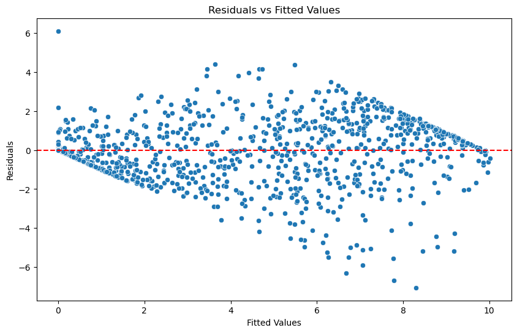

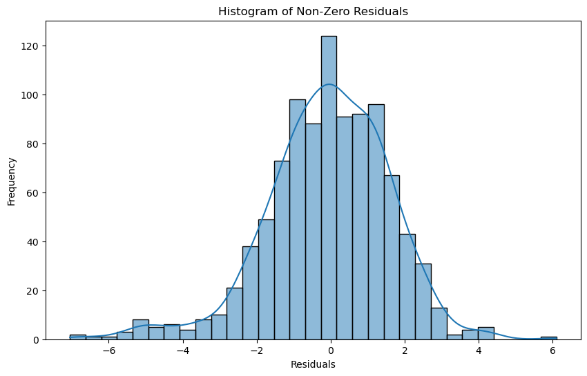

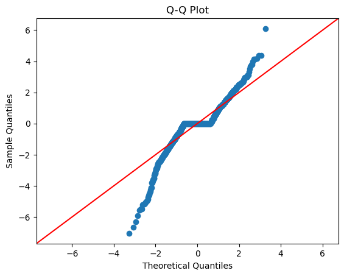

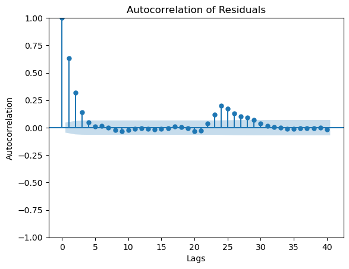

```python
"""
Parameters:
model_data (pd.DataFrame): DataFrame containing 'datetime', 'production', 'predicted_production', and 'residual'
"""
# Residuals vs. Fitted values
plt.figure(figsize=(10, 6))
sns.scatterplot(x=data['predicted_production'], y=data['residual'])
plt.axhline(0, color='red', linestyle='--')
plt.title('Residuals vs Fitted Values')
plt.xlabel('Fitted Values')
plt.ylabel('Residuals')
plt.show()

#Histogram of residuals
non_zero_residuals = data[data['residual'] != 0]['residual']
plt.figure(figsize=(10, 6))
sns.histplot(non_zero_residuals, kde=True)
plt.title('Histogram of Non-Zero Residuals')
plt.xlabel('Residuals')
plt.ylabel('Frequency')
plt.show()

# Q-Q plot of residuals
plt.figure(figsize=(10, 6))
sm.qqplot(data['residual'], line='45')
plt.title('Q-Q Plot')
plt.xlabel('Theoretical Quantiles')
plt.ylabel('Sample Quantiles')
plt.show()

# Autocorrelation plot of residuals
plt.figure(figsize=(10, 6))
sm.graphics.tsa.plot_acf(data['residual'], lags=40)
plt.title('Autocorrelation of Residuals')
plt.xlabel('Lags')
plt.ylabel('Autocorrelation')
plt.show()
```

The significant change can be seen in residuals vs fiteed values because of the number of data points available. Since our test period includes much less datapoint compared to whole data, it shows slightly random behavior around 0.

#### Creating data for fitting ARIMA model to Residuals

Linear regression is fitted until 31st of January to obtain residuals because these residuals will be used to fit ARIMA model

```python
model_1 = LinearRegression()

start_date = pd.to_datetime('2024-02-01')

implementation_df = pd.merge(production_df, weather_info_df, on='datetime', how='inner')
end_data = implementation_df[implementation_df['datetime'] <= start_date]

end_data['lag_3'] = end_data['production'].shift(72)
end_data['TMP_1'] = end_data['TMP_surface'].shift(1)

end_data = end_data[~((end_data['datetime'].dt.hour >= 20) | (end_data['datetime'].dt.hour <= 5))]

end_data['hour'] = end_data['datetime'].dt.hour
end_data['month'] = end_data['datetime'].dt.month

end_data['month_name'] = end_data['month'].apply(lambda x: pd.to_datetime(f'2023-{int(x):02d}-01').strftime('%B') if pd.notna(x) else 'Unknown')

month_dummies = pd.get_dummies(end_data['month_name'], prefix='is')

# Join the dummy variables with the original DataFrame
end_data = pd.concat([end_data, month_dummies], axis=1)

end_data.drop(['month', 'month_name'], axis=1, inplace=True)

hours_to_include = list(range(6, 20))  # This will include 6 to 19

for hour in hours_to_include:
    end_data[f'hour_{hour}'] = (end_data['hour'] == hour).astype(int)

end_data.drop('hour', axis=1, inplace=True)
end_data = end_data.dropna()


Trial_X = end_data.drop(columns=['datetime', 'production'])
Trial_Y = end_data['production']

before_train = model_1.fit(Trial_X , Trial_Y)

pred_trial = model_1.predict(Trial_X)
residuals = Trial_Y - pred_trial

# Predict using the model
end_data['predicted_production'] = model_1.predict(Trial_X)
end_data['predicted_production'] = end_data['predicted_production'].clip(lower=0)

# Calculate residuals
end_data['residual'] = end_data['production'] - end_data['predicted_production']

# Create the new DataFrame
new_df = end_data[['datetime', 'production', 'predicted_production', 'residual']]
new_df

date_range = pd.date_range(start=new_df['datetime'].min().normalize(),
                   end=new_df['datetime'].max().normalize() + pd.Timedelta(days=1) - pd.Timedelta(hours=1),
                   freq='H')

# Create a new dataframe with the complete date range
full_range_df = pd.DataFrame(date_range, columns=['datetime'])

# Merge the new full range dataframe with the original dataframe
# Use an outer join to keep all dates and fill missing values with 0
completed_df = full_range_df.merge(new_df, on='datetime', how='outer').fillna(0)

# Sorting the dataframe to ensure the datetime order is maintained
data_until31jan = completed_df.sort_values(by='datetime').reset_index(drop=True)

data_until31jan.tail(24)
```

|  | datetime | production | predicted_production | residual |
| --- | --- | --- | --- | --- |
| 17424 | 2024-01-31 00:00:00 | 0.00 | 0.000000 | 0.000000 |
| 17425 | 2024-01-31 01:00:00 | 0.00 | 0.000000 | 0.000000 |
| 17426 | 2024-01-31 02:00:00 | 0.00 | 0.000000 | 0.000000 |
| 17427 | 2024-01-31 03:00:00 | 0.00 | 0.000000 | 0.000000 |
| 17428 | 2024-01-31 04:00:00 | 0.00 | 0.000000 | 0.000000 |
| 17429 | 2024-01-31 05:00:00 | 0.00 | 0.000000 | 0.000000 |
| 17430 | 2024-01-31 06:00:00 | 0.01 | 0.000000 | 0.010000 |
| 17431 | 2024-01-31 07:00:00 | 0.79 | 1.210639 | -0.420639 |
| 17432 | 2024-01-31 08:00:00 | 5.60 | 3.027091 | 2.572909 |
| 17433 | 2024-01-31 09:00:00 | 8.86 | 5.156203 | 3.703797 |
| 17434 | 2024-01-31 10:00:00 | 9.89 | 5.524759 | 4.365241 |
| 17435 | 2024-01-31 11:00:00 | 9.85 | 5.793574 | 4.056426 |
| 17436 | 2024-01-31 12:00:00 | 9.83 | 6.066910 | 3.763090 |
| 17437 | 2024-01-31 13:00:00 | 9.73 | 5.515772 | 4.214228 |
| 17438 | 2024-01-31 14:00:00 | 5.11 | 4.088293 | 1.021707 |
| 17439 | 2024-01-31 15:00:00 | 2.35 | 2.629600 | -0.279600 |
| 17440 | 2024-01-31 16:00:00 | 0.62 | 1.541517 | -0.921517 |
| 17441 | 2024-01-31 17:00:00 | 0.00 | 0.022569 | -0.022569 |
| 17442 | 2024-01-31 18:00:00 | 0.00 | 0.000000 | 0.000000 |
| 17443 | 2024-01-31 19:00:00 | 0.00 | 0.000000 | 0.000000 |
| 17444 | 2024-01-31 20:00:00 | 0.00 | 0.000000 | 0.000000 |
| 17445 | 2024-01-31 21:00:00 | 0.00 | 0.000000 | 0.000000 |
| 17446 | 2024-01-31 22:00:00 | 0.00 | 0.000000 | 0.000000 |
| 17447 | 2024-01-31 23:00:00 | 0.00 | 0.000000 | 0.000000 |

**5. Hybrid Model (Linear Regression and ARIMA model on Residuals)**

```python
whole_data = pd.concat([data_until31jan, data]).reset_index(drop=True)

df = whole_data
results_resarima = pd.DataFrame(columns=['date', 'actual'])


test_start_date = datetime(2024, 2, 1, 0, 0)
test_end_date = datetime(2024, 5, 15, 23, 0)

# Loop over each day in the test date range
current_date = test_start_date

while current_date <= test_end_date:
    # Filter the data up to the current date
    train_data = df[df['datetime'] < current_date - pd.Timedelta(days=1)]

    # Fit the auto_arima model without seasonality
    model = auto_arima(train_data['residual'], seasonal=False, stepwise=True, trace=True, suppress_warnings=True)

    forecast = model.predict(n_periods=24)

    # Collect the actual and predicted values
    actual_date = current_date
    actual_values = df[(df['datetime'] == actual_date)]

    predicted_values = forecast

    # Append to the results DataFrame
    for actual, trial, predicted, date, in zip(actual_values['production'], actual_values['predicted_production'], predicted_values, actual_values['datetime']):
        results_resarima = results_resarima.append({'date': date, 'actual': actual, 'lr':trial,
                                             'lr + arima': trial + predicted}, ignore_index=True)

    # Move to the next date (advance by 2 days)
    current_date += timedelta(days=1)

# Set date as index for results DataFrame
results_resarima['date'] = pd.to_datetime(results_resarima['date'])
results_resarima.set_index('date', inplace=True)

results_resarima.reset_index(inplace=True)
results_resarima.rename(columns={'date': 'datetime'}, inplace=True)
results_resarima = results_resarima[['datetime', 'actual', 'lr', 'lr + arima']]

results_resarima
```

The outputs are obtained seperately in a csv file before, since the models take long time to work, I will upload previously obtained results of our models.

```python
file_path = '.\done_df.csv'

# Read the CSV file into a Pandas DataFrame
df = pd.read_csv(file_path)

# Extract only the desired columns
specific_columns_df = df[['datetime','production', 'lr + arima']]
specific_columns_df['residuals_hybrid'] = specific_columns_df['production'] - specific_columns_df['lr + arima']

print(specific_columns_df)
```

```
              datetime  production  lr + arima  residuals_hybrid
0      1.02.2024 00:00         0.0    0.000000          0.000000
1      1.02.2024 01:00         0.0    0.000000          0.000000
2      1.02.2024 02:00         0.0    0.000000          0.000000
3      1.02.2024 03:00         0.0    0.000000          0.000000
4      1.02.2024 04:00         0.0    0.000000          0.000000
...                ...         ...         ...               ...
2515  15.05.2024 19:00         0.0   -0.066306          0.066306
2516  15.05.2024 20:00         0.0    0.000000          0.000000
2517  15.05.2024 21:00         0.0    0.000000          0.000000
2518  15.05.2024 22:00         0.0    0.000000          0.000000
2519  15.05.2024 23:00         0.0    0.000000          0.000000

[2520 rows x 4 columns]
```

Residual Analysis for Hybrid Model

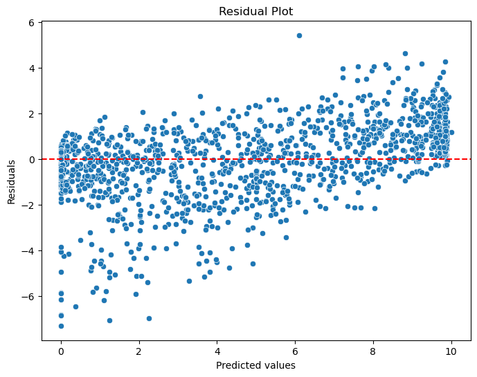

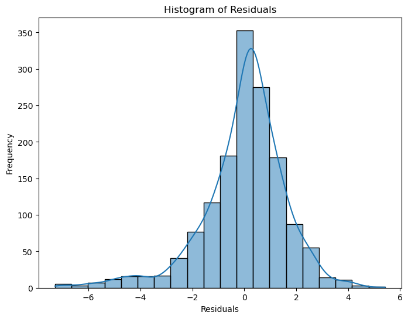

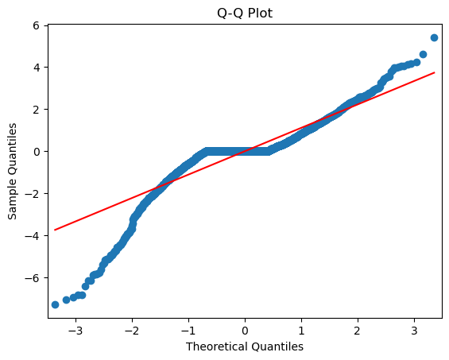

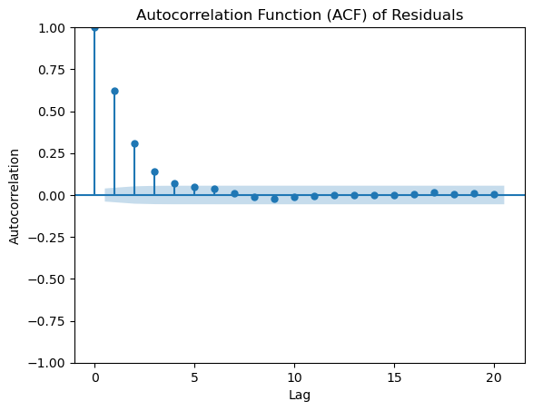

```python
# Residual Plot
plt.figure(figsize=(8, 6))
sns.scatterplot(specific_columns_df["production"], specific_columns_df["residuals_hybrid"])
plt.axhline(y=0, color='r', linestyle='--')
plt.title('Residual Plot')
plt.xlabel('Predicted values')
plt.ylabel('Residuals')
plt.show()

non_zero_residuals = specific_columns_df[specific_columns_df["residuals_hybrid"] != 0]["residuals_hybrid"]
# Histogram of Residuals
plt.figure(figsize=(8, 6))
sns.histplot(non_zero_residuals, bins=20, edgecolor='k',kde=True)
plt.title('Histogram of Residuals')
plt.xlabel('Residuals')
plt.ylabel('Frequency')
plt.show()

# Q-Q Plot (Quantile-Quantile Plot)
sm.qqplot(specific_columns_df["residuals_hybrid"], line='r')
plt.title('Q-Q Plot')
plt.show()

# ACF Plot
sm.graphics.tsa.plot_acf(specific_columns_df["residuals_hybrid"], lags=20)
plt.title('Autocorrelation Function (ACF) of Residuals')
plt.xlabel('Lag')
plt.ylabel('Autocorrelation')
plt.show()
```

Histogram suggests the normal distribution but there is still an improvement for variance because it is a little bit skewed in the left tail

**6. ARIMA Model for each hour seperately**

The idea here is that first running an auto.arima model for each hour seperately and getting p,d,q values for each hour. Afterwards, in the next cell these p,d,q values will be used for each hour in each day in the testing period starting from February 1st to May 15th.

```python
from datetime import datetime, timedelta

# Define list of hours
hours_to_include = range(24)

# Initialize dictionary to store p,d,q values for each hour
pdq_values = {}

# Initialize results DataFrame
results_arima = pd.DataFrame(columns=['date', 'actual', 'predicted'])

# Merge DataFrames
data_arima = pd.merge(production_df, weather_info_df, on='datetime', how='inner')
data_arima_backup = data_arima

# Define test period
test_start_date = datetime(2024, 2, 1, 0, 0)
test_end_date = datetime(2024, 5, 15, 23, 0)


pdq_start_date = test_start_date
# Loop over each hour in the list
for hour in hours_to_include:
    # Filter the data for the hour within the training period
    train_data = data_arima_backup[(data_arima_backup['datetime'] <= (pdq_start_date - pd.Timedelta(hours=1)))]

    # Fit Auto.arima model using data within the training period for this hour
    model = auto_arima(train_data['production'], seasonal=False, stepwise=True, suppress_warnings=True, trace=True)
    pdq_values[hour] = model.order
    pdq_start_date += timedelta(hours=1)
    print(pdq_values)
```

[output not shown]

[output cut: 490 more lines]

[output not shown]

[output not shown]

[output not shown]

[output cut: 78 more lines]

```
 ARIMA(2,1,3)(0,0,0)[0]             : AIC=60991.383, Time=9.89 sec
 ARIMA(1,1,3)(0,0,0)[0]             : AIC=65220.153, Time=4.38 sec
 ARIMA(2,1,2)(0,0,0)[0]             : AIC=61139.657, Time=5.09 sec
 ARIMA(3,1,3)(0,0,0)[0]             : AIC=inf, Time=10.91 sec
 ARIMA(2,1,4)(0,0,0)[0]             : AIC=60923.304, Time=7.10 sec
 ARIMA(1,1,4)(0,0,0)[0]             : AIC=65218.737, Time=3.65 sec
 ARIMA(3,1,4)(0,0,0)[0]             : AIC=60945.064, Time=6.38 sec
 ARIMA(2,1,5)(0,0,0)[0]             : AIC=60868.741, Time=9.23 sec
 ARIMA(1,1,5)(0,0,0)[0]             : AIC=inf, Time=5.85 sec
 ARIMA(3,1,5)(0,0,0)[0]             : AIC=inf, Time=18.82 sec
 ARIMA(2,1,5)(0,0,0)[0] intercept   : AIC=61178.095, Time=23.44 sec

Best model:  ARIMA(2,1,5)(0,0,0)[0]
Total fit time: 238.072 seconds
{0: (3, 1, 2), 1: (2, 1, 5), 2: (2, 1, 5), 3: (3, 1, 2), 4: (3, 1, 2), 5: (3, 1, 2), 6: (3, 1, 2), 7: (3, 1, 2), 8: (3, 1, 2), 9: (3, 1, 2), 10: (2, 1, 5), 11: (3, 1, 2), 12: (3, 1, 2), 13: (2, 1, 3), 14: (3, 1, 2), 15: (3, 1, 2), 16: (3, 1, 2), 17: (3, 1, 2), 18: (3, 1, 2), 19: (3, 1, 2), 20: (3, 1…
```

Below, the p,d,q parameters are taken as input from the previous cell for each hour and ARIMA model is fitted for each hour with this parameters. With the guidance from the professor, since fitting auto.arima for each hour takes too long, **auto.arima is fitted for each hour in advance (see the previous cell) and same parameter set is used for each day**.

The train period is expanded for each day similar to the previous models. However, here, **one important difference in expanding retraining period method** is that I am **expanding the window in an hourly manner**. This method provides better residuals compared to daily expanded train data.

```python
# Loop over each day in the test date range

results_arima = pd.DataFrame(columns=['date', 'actual', 'predicted'])
current_date = test_start_date
while current_date <= test_end_date:
    # Loop over each hour in the list
    for hour in hours_to_include:
        # Filter the data for the hour and current date
        df_hour_current_date = data_arima_backup[(data_arima_backup['datetime'].dt.hour == hour) & (data_arima_backup['datetime'].dt.date == current_date.date())]

        # Get p,d,q values from dictionary
        p, d, q = pdq_values[hour]

        # Filter the data up to the current date
        train_data_expanded = data_arima_backup[(data_arima_backup['datetime'] <= (current_date - pd.Timedelta(hours=1)))]

        #add the data of today's until this hour
        # train_data_expanded = pd.concat([train_data_expanded, df_hour_current_date], ignore_index=True)
        # Fit ARIMA model with the specified p,d,q values
        model = ARIMA(train_data_expanded['production'], order= pdq_values[hour])

        # Forecast for the next hour
        fit = model.fit()
        forecast = fit.forecast(steps=1)
        # Collect the actual and predicted values
        actual_date = current_date
        actual_values = data_arima_backup[(data_arima_backup['datetime'] == actual_date)]

        predicted_values = forecast

        # Append to the results DataFrame
        for actual, predicted, date in zip(df_hour_current_date['production'], predicted_values, actual_values['datetime']):
            new_row = pd.DataFrame({'date': [date], 'actual': [actual], 'predicted': [predicted]})
            results_arima = pd.concat([results_arima, new_row], ignore_index=True)
            # Move to the next date (advance by 1 day)
        current_date += timedelta(hours=1)

        print("Hour: ", hour)

    results_arima.to_csv('results_arima.csv')

# Set date as index for results DataFrame
results_arima.set_index('date', inplace=True)


# Display p,d,q values for each hour
print(pdq_values)

# save the results to a csv file
results_arima.to_csv('results_arima.csv')
```

```python
## Here please import rsults_arima and add arima values under arima_hourly header
file_path = 'results_arima.csv'

# Read the CSV file into a Pandas DataFrame
results_arima = pd.read_csv(file_path)


df['arima_hourly'] = results_arima['predicted']

specific_columns_df = df[['datetime','production', 'arima_hourly']]
specific_columns_df['residuals_arima_hourly'] = specific_columns_df['production'] - specific_columns_df['arima_hourly']

print(specific_columns_df)
```

```
              datetime  production  arima_hourly  residuals_arima_hourly
0      1.02.2024 00:00         0.0      0.402281               -0.402281
1      1.02.2024 01:00         0.0      0.549963               -0.549963
2      1.02.2024 02:00         0.0      0.691163               -0.691163
3      1.02.2024 03:00         0.0      0.791852               -0.791852
4      1.02.2024 04:00         0.0      0.888389               -0.888389
...                ...         ...           ...                     ...
2515  15.05.2024 19:00         0.0      0.150000               -0.150000
2516  15.05.2024 20:00         0.0      0.000000                0.000000
2517  15.05.2024 21:00         0.0      0.000000                0.000000
2518  15.05.2024 22:00         0.0      0.000000                0.000000
2519  15.05.2024 23:00         0.0      0.000000                0.000000

[2520 rows x 4 columns]
```

Residual Analysis of Hourly ARIMA Model

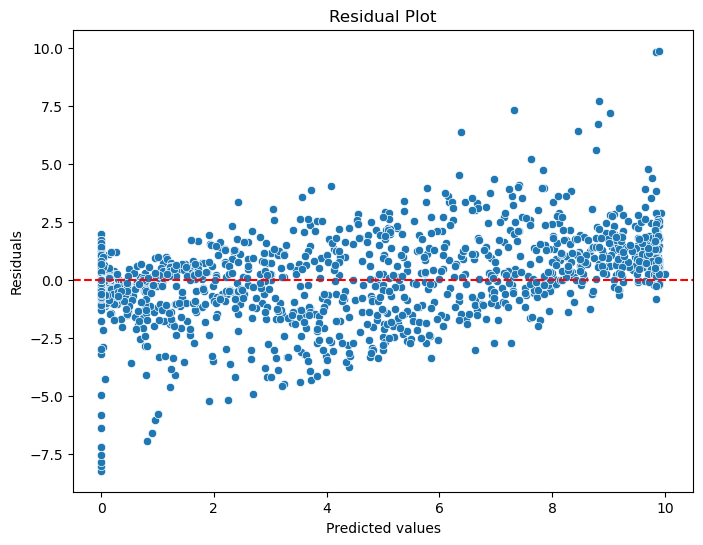

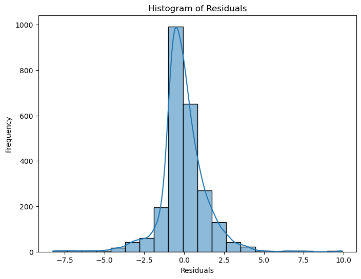

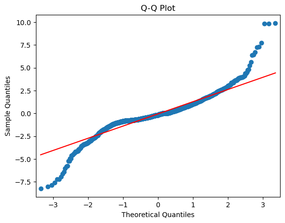

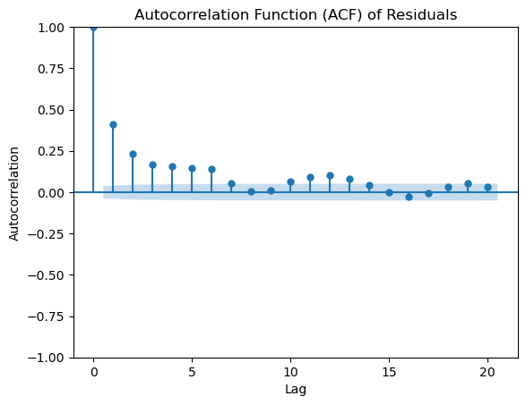

```python
# Residual Plot
plt.figure(figsize=(8, 6))
sns.scatterplot(specific_columns_df["production"], specific_columns_df["residuals_arima_hourly"])
plt.axhline(y=0, color='r', linestyle='--')
plt.title('Residual Plot')
plt.xlabel('Predicted values')
plt.ylabel('Residuals')
plt.show()

non_zero_residuals = specific_columns_df[specific_columns_df["residuals_arima_hourly"] != 0]["residuals_arima_hourly"]
# Histogram of Residuals
plt.figure(figsize=(8, 6))
sns.histplot(non_zero_residuals, bins=20, edgecolor='k',kde=True)
plt.title('Histogram of Residuals')
plt.xlabel('Residuals')
plt.ylabel('Frequency')
plt.show()

# Q-Q Plot (Quantile-Quantile Plot)
sm.qqplot(specific_columns_df["residuals_arima_hourly"], line='r')
plt.title('Q-Q Plot')
plt.show()

# ACF Plot
sm.graphics.tsa.plot_acf(specific_columns_df["residuals_arima_hourly"], lags=20)
plt.title('Autocorrelation Function (ACF) of Residuals')
plt.xlabel('Lag')
plt.ylabel('Autocorrelation')
plt.show()
```

The histogram plot is plotted on non zero residuals, However, again it deviates form normality compared to linear regression models.

We would expect ARIMA model to perform better in ACF function since it integrates AR model and MA model and also differencing. However, there is a large positive lag in lag 1. Therefore maybe one more round of differencing or lag(1) term can be added as regressor

**7. Seasonal ARIMA Model**

```python
data_sarima = pd.merge(production_df, weather_info_df, on='datetime', how='inner')
results_sarima = pd.DataFrame(columns=['date', 'actual', 'predicted'])

df = data_sarima

test_start_date = datetime(2023, 2, 1, 0, 0)
test_end_date = datetime(2023, 2, 1, 23, 0)

# Loop over each day in the test date range
current_date = test_start_date

while current_date <= test_end_date:
    # Filter the data up to the current date
    train_data = df[df['datetime'] < current_date - pd.Timedelta(days=1)]

    # Fit the auto_arima model without seasonality
    model = auto_arima(train_data['production'],
                   seasonal=True,
                   m=24,  # 24-hour seasonality
                   stepwise=True,
                   suppress_warnings=True,
                      trace= True)

    # Forecast the next 2 days
    forecast = model.predict(n_periods=24)

    # Collect the actual and predicted values
    actual_date = current_date
    actual_values = df[(df['datetime'] == actual_date)]

    predicted_values = forecast

    # Append to the results DataFrame
    for actual, predicted, date in zip(actual_values['production'], predicted_values, actual_values['datetime']):
        results = results.append({'date': date, 'actual': actual, 'predicted': predicted}, ignore_index=True)

    # Move to the next date (advance by 2 days)
    current_date += timedelta(days=1)

# Set date as index for results DataFrame
results_sarima['date'] = pd.to_datetime(results['date'])
results_sarima.set_index('date', inplace=True)
```

```python
specific_columns_df = df[['datetime','production', 'sarima']]
specific_columns_df['residuals_sarima'] = specific_columns_df['production'] - specific_columns_df['sarima']

print(specific_columns_df)
```

```
                 datetime  production        sarima  residuals_sarima
0     2024-02-01 00:00:00         0.0  0.000000e+00      0.000000e+00
1     2024-02-01 01:00:00         0.0  0.000000e+00      0.000000e+00
2     2024-02-01 02:00:00         0.0  0.000000e+00      0.000000e+00
3     2024-02-01 03:00:00         0.0  0.000000e+00      0.000000e+00
4     2024-02-01 04:00:00         0.0  0.000000e+00      0.000000e+00
...                   ...         ...           ...               ...
2515  2024-05-15 19:00:00         0.0  3.003259e-07     -3.003259e-07
2516  2024-05-15 20:00:00         0.0  4.772338e-06     -4.772338e-06
2517  2024-05-15 21:00:00         0.0  0.000000e+00      0.000000e+00
2518  2024-05-15 22:00:00         0.0  0.000000e+00      0.000000e+00
2519  2024-05-15 23:00:00         0.0  0.000000e+00      0.000000e+00

[2520 rows x 4 columns]
```

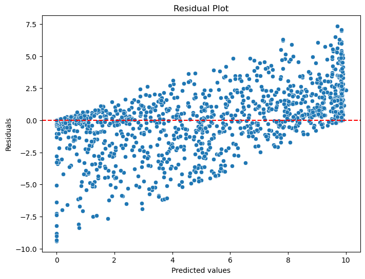

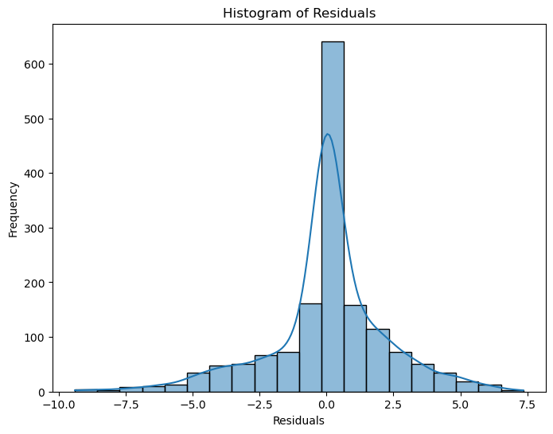

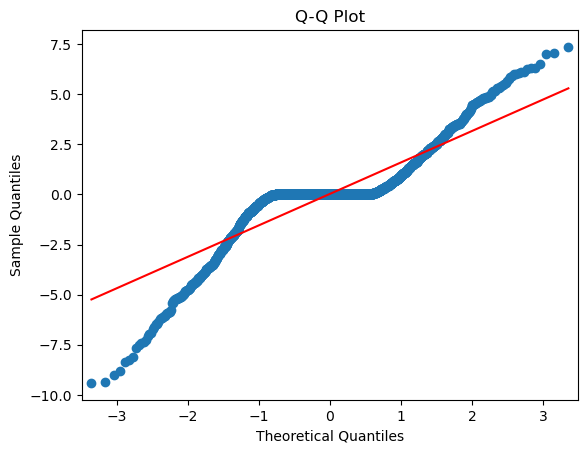

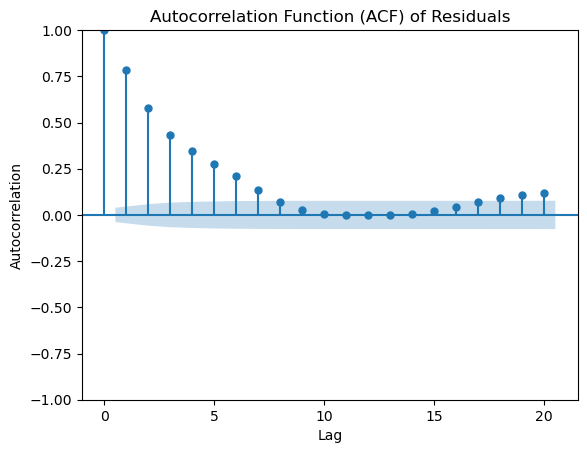

```python
# Residual Plot
plt.figure(figsize=(8, 6))
sns.scatterplot(specific_columns_df["production"], specific_columns_df["residuals_sarima"])
plt.axhline(y=0, color='r', linestyle='--')
plt.title('Residual Plot')
plt.xlabel('Predicted values')
plt.ylabel('Residuals')
plt.show()

non_zero_residuals = specific_columns_df[specific_columns_df["residuals_sarima"] != 0]["residuals_sarima"]
# Histogram of Residuals
plt.figure(figsize=(8, 6))
sns.histplot(non_zero_residuals, bins=20, edgecolor='k',kde=True)
plt.title('Histogram of Residuals')
plt.xlabel('Residuals')
plt.ylabel('Frequency')
plt.show()


# Q-Q Plot (Quantile-Quantile Plot)
sm.qqplot(specific_columns_df["residuals_sarima"], line='r')
plt.title('Q-Q Plot')
plt.show()

# ACF Plot
sm.graphics.tsa.plot_acf(specific_columns_df["residuals_sarima"], lags=20)
plt.title('Autocorrelation Function (ACF) of Residuals')
plt.xlabel('Lag')
plt.ylabel('Autocorrelation')
plt.show()
```

The histogram plot is plotted on non zero residuals like in the ARIMA model, However, again it deviates form normality compared to linear regression models.

We would expect ARIMA model to perform better in ACF function since it integrates AR model and MA model and also differencing. However, it performs worse than the linear models.

**8. Model Comparisons**

The main comparison metric is weighted mean absolute percentage error (WMAPE) and 4 different models are compared.

```
1. Linear Regression Model
2. Hybrid Model (Linear Regression and ARIMA model on Residuals)
3. ARIMA Model
4. Seasonal ARIMA Model
```

```python
final = pd.read_csv('./done_df.csv')
final['datetime'] = pd.to_datetime(final['datetime'])


# Calculate WMAPE
# Calculate WMAPE
def calculate_wmape(actual, predicted):
    denominator = sum(abs(actual))
    if denominator == 0:
        return np.nan
    return sum(abs(actual - predicted)) / denominator

# Daily WMAPE
final['date'] = final['datetime'].dt.date
daily_wmape = final.groupby('date').apply(lambda x: pd.Series({
    'wmape_arima': calculate_wmape(x['production'], x['arima_hourly']),
    'wmape_sarima': calculate_wmape(x['production'], x['sarima']),
    'wmape_lr': calculate_wmape(x['production'], x['lr']),
    'wmape_lr_arima': calculate_wmape(x['production'], x['lr + arima'])
})).reset_index()

# Monthly WMAPE
final['month'] = final['datetime'].dt.to_period('M')
monthly_wmape = final.groupby('month').apply(lambda x: pd.Series({
    'wmape_arima': calculate_wmape(x['production'], x['arima_hourly']),
    'wmape_sarima': calculate_wmape(x['production'], x['sarima']),
    'wmape_lr': calculate_wmape(x['production'], x['lr']),
    'wmape_lr_arima': calculate_wmape(x['production'], x['lr + arima'])
})).reset_index()

# Overall WMAPE
overall_wmape = pd.DataFrame({
    'wmape_arima': [calculate_wmape(final['production'], final['arima_hourly'])],
    'wmape_sarima': [calculate_wmape(final['production'], final['sarima'])],
    'wmape_lr': [calculate_wmape(final['production'], final['lr'])],
    'wmape_lr_arima': [calculate_wmape(final['production'], final['lr + arima'])]
})

def pretty_print(df, title):
    table = PrettyTable()
    table.field_names = df.columns.tolist()
    for row in df.itertuples(index=False):
        formatted_row = [f"{x:.5f}" if isinstance(x, (float, int)) else x for x in row]
        table.add_row(formatted_row)
    table.title = title
    print(table)
```

```python
pretty_print(daily_wmape, "Daily WMAPE")
pretty_print(monthly_wmape, "Monthly WMAPE")
pretty_print(overall_wmape, "Overall WMAPE")
```

```
+---------------------------------------------------------------------+
|                             Daily WMAPE                             |
+------------+-------------+--------------+----------+----------------+
|    date    | wmape_arima | wmape_sarima | wmape_lr | wmape_lr_arima |
+------------+-------------+--------------+----------+----------------+
| 2024-01-02 |   0.49783   |   0.45044    | 0.45676  |    0.46702     |
| 2024-01-03 |   0.29780   |   0.10309    | 0.24618  |    0.21285     |
| 2024-01-04 |   0.37862   |   0.23593    | 0.33163  |    0.30800     |
| 2024-01-05 |   0.86461   |   0.75948    | 0.53526  |    0.65143     |
| 2024-02-02 |   0.32285   |   0.36842    | 0.26187  |    0.27427     |
| 2024-02-03 |   0.34045   |   0.18487    | 0.21514  |    0.17288     |
| 2024-02-04 |   0.25237   |   0.12833    | 0.10677  |    0.07965     |
| 2024-02-05 |   0.36848   |   0.38389    | 0.35118  |    0.28819     |
| 2024-02-13 |   0.58605   |   1.20221    | 0.47284  |    0.45036     |
| 2024-02-14 |   0.43059   |   1.05881    | 0.56821  |    0.69810     |
| 2024-02-15 |   0.42241   |   0.32103    | 0.41038  |    0.32564     |
| 2024-02-16 |   0.40860   |   0.44340    | 0.24179  |    0.22016     |
| 2024-02-17 |   0.68873   |   1.03855    | 0.96235  |    1.00494     |
| 2024-02-18 |   0.94261   |   3.00869    | 3.09988  |    3.15889     |
| 2024-02-19 |   0.55133   |   0.75256    | 1.27760  |    1.16190     |
| 2024-02-20 |   0.33301   |   0.66179    | 0.21468  |    0.22307     |
| 2024-02-21 |   0.36129   |   0.68209    | 0.33755  |    0.32303     |
| 2024-02-22 |   0.79374   |   0.54991    | 0.49002  |    0.55700     |
| 2024-02-23 |   0.54589   |   0.23507    | 0.40207  |    0.34226     |
| 2024-02-24 |   0.26798   |   0.37951    | 0.20183  |    0.22127     |
| 2024-02-25 |   0.25225   |   0.43741    | 0.22280  |    0.22183     |
| 2024-02-26 |   0.39103   |   0.21915    | 0.12310  |    0.21340     |
| 2024-02-27 |   0.46110   |   0.22617    | 0.23609  |    0.22240     |
| 2024-02-28 |   0.25483   |   0.16965    | 0.15006  |    0.16823     |
| 2024-02-29 |   0.23835   |   0.23830    | 0.18314  |    0.17109     |
| 2024-03-02 |   0.34896   |   0.17268    | 0.20330  |    0.19620     |
| 2024-03-03 |   0.75439   |   1.93406    | 1.11563  |    1.12777     |
| 2024-03-04 |   0.24663   |   0.08577    | 0.19021  |    0.15439     |
| 2024-03-05 |   0.60709   |   0.37202    | 0.40828  |    0.39312     |
| 2024-03-13 |   0.34286   |   0.31699    | 0.26674  |    0.24502     |
| 2024-03-14 |   0.38535   |   0.23826    | 0.28214  |    0.25664     |
| 2024-03-15 |   0.55218   |   0.76146    | 0.36843  |    0.35593     |
| 2024-03-16 |   0.42970   |   0.20285    | 0.29906  |    0.22404     |
| 2024-03-17 |   0.26199   |   0.22353    | 0.20246  |    0.21091     |
| 2024-03-18 |   0.47934   |   0.43174    | 0.33599  |    0.35677     |
```

[output cut: 81 more lines]

[output not shown]

As seen above in the Weighted Mean Absolute Percentage Error Table for 4 models, the lowest WMAPE belongs to the hybrid model which is composed of linear regression and arima model on residuals. Therefore, **hybrid model is chosen to predict production.**

#### Brief Summary of Models:

```
1. Linear Regression Model
```

The Linear Regression model involves several steps for data preparation and feature engineering to capture the underlying patterns in solar production data.

Lagged Variable: A lag of 72 hours is added as a predictor, excluding lag(24) and lag(48) due to the data structure. Hour Filter: Production data outside the hours of 6:00 and 19:00 is filtered out, as it is typically zero.

Lagged Temperature: A 1-hour lag is introduced for the surface temperature variable to account for the delayed effect of heat accumulation.

Hourly and Monthly Dummy Variables: Seasonal dummy variables are added to account for hourly sunlight variation and monthly seasonal effects.

```
2. Hybrid Model (Linear Regression + ARIMA on Residuals)
```

This model first applies the Linear Regression model as described above. The residuals (errors) from this regression until december 31st are then modeled by using an ARIMA model. The ARIMA model captures the remaining time series patterns in the residuals. Afterwards, prediction from LR model and arima residuals are combined for prediction.

```
3. Hourly ARIMA Model
```

The Hourly ARIMA Model fits separate ARIMA models for each hour of the day.

Auto.ARIMA for Each Hour: ARIMA parameters (p, d, q) are determined for each hour using auto.arima.

Hourly Expanding Window: The training data window is expanded in an hourly manner, which provides better residuals compared to daily expansion.

```
4. SARIMA Model
```

The Seasonal ARIMA (SARIMA) model extends the ARIMA model by incorporating seasonal components to capture periodic fluctuations in the data. Like the other models, it uses an expanding window approach for the training period.

#### Performance Analysis

*Linear Regression Model (WMAPE: 0.28179):*

This model performs relatively well, benefiting from the addition of lagged variables, temperature adjustments, and seasonal dummy variables. However, it might still miss capturing complex non-linear relationships and finer time series patterns.

*Hybrid Model (WMAPE: 0.26571):*

The best-performing model. Combining Linear Regression with ARIMA on residuals leverages the strengths of both approaches. Linear Regression captures the linear trend and seasonality, while ARIMA effectively models the remaining time series patterns in the residuals.

*Hourly ARIMA Model (WMAPE: 0.37142):*

The least accurate model. While it captures hour-specific patterns, the lack of integration between hours might result in losing broader trends and seasonal effects. Moreover, fitting ARIMA separately for each hour can lead to inconsistencies and increased computational complexity.

*SARIMA Model (WMAPE: 0.35638):*

Performs better than the standard ARIMA but worse than the Linear Regression and Hybrid models. While it captures seasonality, it may not effectively model the linear trends and finer residual patterns as the Hybrid model does. Hypotheses for Performance Differences

#### Model Complexity and Flexibility:

Linear Regression: Captures basic trends and seasonality but misses complex patterns.

Hybrid Model: Combines strengths of Linear Regression and ARIMA, handling both linear and non-linear aspects, leading to the best performance.

ARIMA: Focuses on past values and errors without seasonality, which might not be sufficient for complex solar production data.

SARIMA: Adds seasonality but may not fully capture the linear trends and intricate patterns that the Hybrid model does.

#### Handling of Seasonality and Trends:

Linear Regression: May not fully handle seasonality, crucial for solar production data.

ARIMA: Lacks seasonal components, explaining its poorer performance.

SARIMA: Improves on ARIMA by adding seasonality but still misses some linear trends.

#### Residual Analysis:

The Hybrid Model benefits from modeling residuals separately, capturing time series patterns that Linear Regression alone might miss.

#### Data Characteristics:

Solar production data has strong seasonal and trend components. Models like the Hybrid Model, which handle both effectively, perform better.

#### Conclusion

The Hybrid Model (Linear Regression + ARIMA on Residuals) outperforms other models by effectively capturing both linear trends and time series patterns in the residuals. This comprehensive approach addresses the limitations of the individual Linear Regression and ARIMA models, resulting in more accurate forecasts.

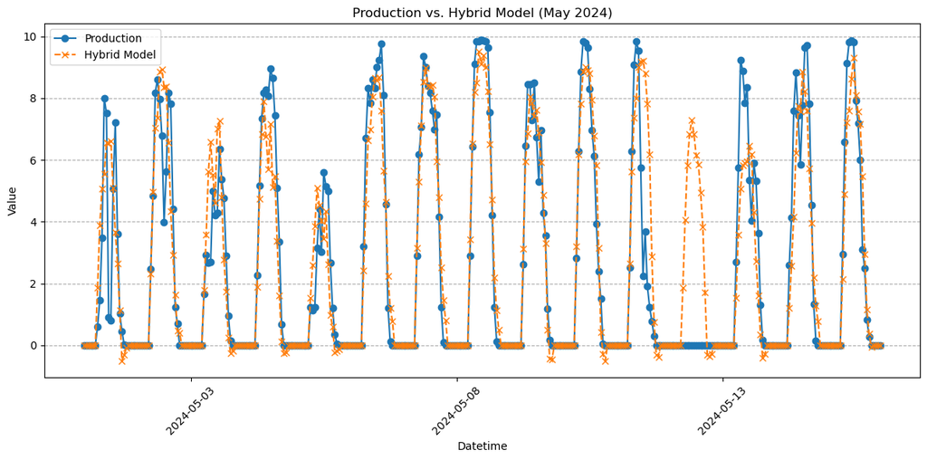

```python
import matplotlib.dates as mdates

# Read the CSV file
file_path = 'done_df.csv'
df = pd.read_csv(file_path)

df['datetime'] = pd.to_datetime(df['datetime'])

# Filter data between May 1st and 30th, 2024
final_df = df[
    (df['datetime'] >= '2024-05-01') & (df['datetime'] <= '2024-05-20')
]

# Plotting
plt.figure(figsize=(12, 6))  # Adjust figure size as needed

# Plot 'production' and 'lr + arima'
plt.plot(final_df['datetime'], final_df['production'], marker='o', linestyle='-', label='Production')
plt.plot(final_df['datetime'], final_df['lr + arima'], marker='x', linestyle='--', label='Hybrid Model')

# Formatting
plt.xlabel('Datetime')
plt.ylabel('Value')
plt.title('Production vs. Hybrid Model (May 2024)')
plt.legend()

# Customize x-axis date formatting
plt.gca().xaxis.set_major_formatter(mdates.DateFormatter('%Y-%m-%d'))
plt.gca().xaxis.set_major_locator(mdates.DayLocator(interval=5))  # Show every 5 days
plt.xticks(rotation=45)

plt.tight_layout()
plt.grid(axis='y', linestyle='--')
plt.show()
```

### Suggestion for Further Improvement

We have seen that combination of linear regression models and time series methods like ARIMA on residuals perform the best. One can apply auto.arima on residuals for each hour like we did in the hourly ARIMA model and combine the results with the linear regression to get better fitted ARIMA parameters.

Also for the linear regression part, more lagged variables could be added but we need to be careful about over-fitting.

Also, instead of adding hourly and monthly dummy variables, continuous seasonality variables like Fourier series could be fitted.